# PRA2_Tipologia_DataCleaning

[figure not shown]

Tipología y Ciclo de Vida de los Datos - PR2

2018-19 · Máster en Ciencia de datos

Pablo Lombao Vázquez

# Data Cleaning: Precios de la energía en el Mercado Ibérico

## 1. Introducción

### 1.1. Descripción del dataset

El conjunto de datos está compuesto por los datos oficiales de la OMIE del precio horario de la energía en EUR/MWh para el mercado ibérico de energía (España y Portugal), a parte del total de Compras y Ventas de energía para los mercados ES y PT, extraidos de la página de la OMIE.es mediante web scraping para las fechas que abarcan desde el 2 de Junio hasta el 20 de Octubre de 2018.

Para cada hora se registra el momento y 10 variables numéricas de mercado siendo por tanto de 11 atributos totales. Los datos originales corresponden a Fecha, Precio del Mercado (En España y Portugal), Ventas y Compras en España, en Portugal y el total de ambos países sumados. **En el apartado 2 se justifican las variables eliminadas para el análisis** ya que de estos 11 atributos nos quedaremos con 4: Fecha, Precio, Ventas y Compras debido a que el resto de los atributos numéricos están altamente relacionados. Por otro lado, el atributo Fecha esconde en sí mismo varios atributos interesantes: fecha, hora, día de la semana o estación.

- **Fecha**: fecha y hora de la medida (un registro por cada hora)
- **Precio**: precio de la energía en euros por MWh
- **Ventas**: ventas de energía en el mercado ibérico de energía en GWh
- **Compras**: compras de energía realizadas por el mercado ibérico en GWh
- **hour**: hora del día
- **dayofyear**: día del año
- **dayofweek**: día de la semana
- **quarter**: cuatrimestre del año
- **month**: mes del año
- **night**: variable dummie que determina si la medida ocurre de noche (23 a 07)
- **weekend**: variable dummie que determina si es fin de semana (sabado y domingo)

### 1.2. Objetivos

El presente documento tiene como objetivo el estudio analítico del precio de la energía en el mercado ibérico y su comportamiento en relación a la estacionalidad, en concreto queremos saber:

- Missings y outliers que contiene el conjunto de datos y como tratarlos.
- Diferencia en el comportamiento del precio de la energía entre un día entre semana y un día de finde.
- Modelización del comportamiento del precio de la energía respecto a las variables de estacionalidad (hora, día de la semana, mes...).

## 2. Integración y selección de datos

En este apartado se construye y se justifica la selección de atributos para su posterior análisis, construyendo y eliminando atributos.

```python
%matplotlib inline

import pandas as pd
import numpy as np
import matplotlib.pyplot as plt
import seaborn as sns

import warnings
warnings.filterwarnings('ignore')
```

```python
# Importamos los datos
df = pd.read_csv('OMIE_20180601_20181020.csv', parse_dates=True)

# Cambiamos el formato de la columna Fecha a datetime
df['Fecha'] = df['Fecha'].apply(pd.to_datetime, format = '%d/%m/%Y %H:%M', errors='coerce')

# Ponemos la fecha como indice
df = df.set_index('Fecha')
```

De un primer vistazo al dataset ya nos damos cuenta e que hay variables que son en realidad la misma, vamos a realizar unas pequeñas representaciones gráficas para poder descartar datos que no son de interés.

```python
# Comprobamos que la columna 0 y 2 son iguales
((df.iloc[:,0] - df.iloc[:,2])>0).sum()
```

```
0
```

```python
# Comprobamos que la columna 1 y 3 son iguales
((df.iloc[:,1] - df.iloc[:,3])>0).sum()
```

```
0
```

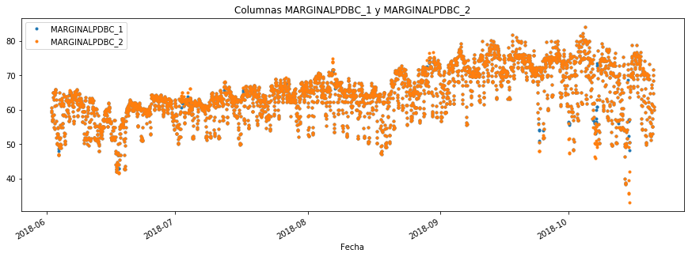

```python
_ = df.iloc[:,[0,1]].plot(style='.', figsize=(15,5), title='Columnas MARGINALPDBC_1 y MARGINALPDBC_2')
```

Por otra parte, vamos a crear unos indicativos de temporalidad a partir del campo fecha: hora, día de la semana, mes y cuatrimestre del año.

```python
def create_features(df, label=None):
    """
    Creates time series features from datetime index
    """
    df['date'] = df.index
    df['hour'] = df['date'].dt.hour
    df['dayofyear'] = df['date'].dt.dayofyear
    df['weekday'] = df['date'].dt.dayofweek
    df['quarter'] = df['date'].dt.quarter
    df['month'] = df['date'].dt.month
    df['night'] = np.logical_or(df['hour']<8,df['hour']>22)
    df['weekend'] = df['weekday']>4

    return df

df = create_features(df)
df = df.iloc[:,[0,8,9,11,12,13,14,15,16,17]]
df.columns = ['Precio','Compras','Ventas'] + list(df.columns[-7:])
df.head()
```

| Fecha | Precio | Compras | Ventas | hour | dayofyear | weekday | quarter | month | night | weekend |
| --- | --- | --- | --- | --- | --- | --- | --- | --- | --- | --- |
| 2018-06-02 00:00:00 | 60.69 | 23658.9 | 21458.9 | 0 | 153 | 5 | 2 | 6 | True | True |
| 2018-06-02 01:00:00 | 59.74 | 22318.6 | 20118.6 | 1 | 153 | 5 | 2 | 6 | True | True |
| 2018-06-02 02:00:00 | 59.30 | 20840.6 | 19340.6 | 2 | 153 | 5 | 2 | 6 | True | True |
| 2018-06-02 03:00:00 | 58.33 | 19945.6 | 18445.6 | 3 | 153 | 5 | 2 | 6 | True | True |
| 2018-06-02 04:00:00 | 58.00 | 19345.1 | 17845.1 | 4 | 153 | 5 | 2 | 6 | True | True |

Este es el aspecto que tendrá el conjunto de datos de trabajo desde aquí en adelante, tal y como lo habíamos definido en la primera sección.

## 3. Data cleaning

Vamos a proceder a limpiar los datos y particularmente, a estudiar y corregir los outliers y missings.

### 3.1. Missings

Los missings o valores perdidos se tratan de valores nulos o vacíos que corresponden a valores no válidos de nuestro conjunto de datos, ya sea por que se han perdido, porque están corruptos, porque no existe la información o porque no se tomó adecuadamente.

```python
def report_missings(data, return_missings=False):
    """
    Coge un dataframe, informa de sus missings
    y si lo indicamos, devuelve una tabla con las
    columnas con missings, el número de missings y
    el porcentaje de missings
    """
    # getting the sum of null values and ordering
    total = data.isnull().sum().sort_values(ascending = False)
    # getting the percent and order of null
    percent = (data.isnull().sum() / data.isnull().count() * 100 ).sort_values(ascending = False)
    # Concatenating the total and percent
    df = pd.concat([total, percent], axis=1, keys=['Total', 'Percent'])
    # Returning values of nulls different of 0
    missings = df[~(df['Total'] == 0)]
    print("MISSINGS VALUES REPORT:")
    print(missings)
    print("==============================================================")
    total = missings.sum(axis=0)
    print("Total Missings in the df: {} value/s".format(str(int(total[0]))))
    print("Total % of Missings in the df: {} %".format(str(round(total[1],2))))
    print("==============================================================")
    print("Total rows: {}".format(str(data.shape)))
    print("Total rows with NO missings in df: {} rows".format(str(data.dropna().shape[0])))

    if return_missings: return missings

report_missings(df)
```

[output not shown]

Como vemos **no tenemos missings en nuestro conjunto de datos**.

Si los tuvieramos, podríamos usar las siguientes thumb rules:

- Eliminar columnas por encima del 60-70% de missings para variables no fundamentales.
- Eliminar filas con más de dos variables missings.
- Asignar el resto de missings.

El método podría ser el de **interpolación lineal con correcciones estacionales** debido a que se trata de un time-series sobre la que podemos asumir que sigue una tendencia y que es estacional (depende de variables temporales como época del año, día...).

Otros métodos que podríamos usar sobre nuestros datos para imputación de missings:

- Asignación mediante valores de tendencia central: media, media recortada, mediana o media winsorizada
- Asignación mediante ratio imputation
- Modelo de regresión lineal o logística
- Imputación mediante técnicas de Machine Learning como el algoritmo kNN, XGBoost o Random Forest.

Teniendo en cuenta que es una timeseries, tendría más sentido realizar una imputación de missings usando las siguientes técncias:

- backfilling: consiste en asignar el valor anterior del valor perdido
- forwardfilling: consiste en asignar el valor posterior al valor perdido
- interpolation (lineal o no lineal): consiste en asignar un valor intermedio entre el anterior y el posterior siguiendo técnicas lineales (una recta) o no lineales.

### 3.2. Outliers

Los outliers son valores extremos que se desmarcan del rango "esperado" para una determinada distribución univariable. Estos valores afectan en gran medida a los análisis realizados sobre dichos datos, alterando los resultados. No obstante, no todos los outliers son en realidad valores no válidos sino que depende de la naturaleza de la medida y del contexto concreto. Matemáticamente podemos definir a los outliers de dos formas distintas:

- Método Zscore: Valores que estén a una distancia de la media igual o mayor a 3 veces la desviación estándar, cuya probabilidad de aparición es de 0.26% para distribuciones normales.
- Método RIC: Valores a más de 1.5 veces el rango intercuartílico de la distribución (distancia entre el perceptil 75 y el 25)

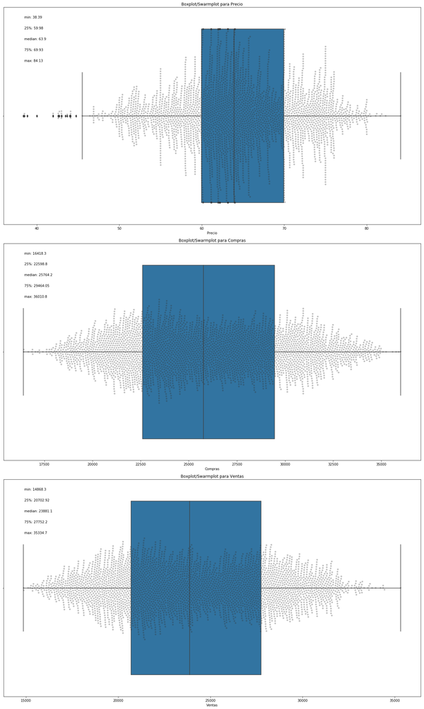

```python
def plotBoxSwarm(data):
    sns.boxplot(data)
    ax = sns.swarmplot(data, color=".2", alpha=0.3)
    plt.title('Boxplot/Swarmplot para {}'.format(data.name))
    ytext=0.95
    for quan, name in zip([0, 0.25, 0.5, 0.75, 1],['min','25%','median','75%','max']):
        ax.text(0.05, ytext,name +': {}'.format(round(data.quantile(quan),2)),
            transform=ax.transAxes)
        ytext -= 0.05

plt.figure(figsize=(18, 30))
i=1
for column in df.columns[0:3]:
    plt.subplot(3,1,i)
    plotBoxSwarm(df[column])
    i+=1
plt.tight_layout()
plt.show()
```

```python
data = df['Precio']
# Calculamos los quartiles q1, q3
q1, q3 = data.quantile(0.25), data.quantile(0.75)
# Calculamos el RIC
ric = q3 - q1
# Calculamos la matriz mask de outliers
mask = (data < (q1 - 1.5*ric)) | (data > (q3 + 1.5*ric))
outliers = df[mask]
# Calculamos el numero de outliers por columna
print("OUTLIERS VALUES REPORT - RIC method:")
print("Total outliers: {}".format(len(outliers)))
print("==============================================================")
outliers
```

```
OUTLIERS VALUES REPORT - RIC method:
Total outliers: 21
==============================================================
```

| Fecha | Precio | Compras | Ventas | hour | dayofyear | weekday | quarter | month | night | weekend |
| --- | --- | --- | --- | --- | --- | --- | --- | --- | --- | --- |
| 2018-06-17 02:00:00 | 44.10 | 19423.2 | 17623.2 | 2 | 168 | 6 | 2 | 6 | True | True |
| 2018-06-17 03:00:00 | 43.49 | 19029.2 | 17229.2 | 3 | 168 | 6 | 2 | 6 | True | True |
| 2018-06-17 04:00:00 | 42.74 | 18836.3 | 17036.3 | 4 | 168 | 6 | 2 | 6 | True | True |
| 2018-06-17 05:00:00 | 42.61 | 18674.8 | 16874.8 | 5 | 168 | 6 | 2 | 6 | True | True |
| 2018-06-17 06:00:00 | 41.98 | 18478.7 | 16678.7 | 6 | 168 | 6 | 2 | 6 | True | True |
| 2018-06-17 07:00:00 | 41.98 | 18449.4 | 16649.4 | 7 | 168 | 6 | 2 | 6 | True | True |
| 2018-06-17 08:00:00 | 42.99 | 18740.1 | 16940.1 | 8 | 168 | 6 | 2 | 6 | False | True |
| 2018-06-17 09:00:00 | 44.10 | 20190.2 | 18390.2 | 9 | 168 | 6 | 2 | 6 | False | True |
| 2018-06-17 10:00:00 | 44.10 | 21294.7 | 19494.7 | 10 | 168 | 6 | 2 | 6 | False | True |
| 2018-06-17 11:00:00 | 44.76 | 22274.4 | 20524.4 | 11 | 168 | 6 | 2 | 6 | False | True |
| 2018-06-17 18:00:00 | 42.99 | 23298.8 | 20448.8 | 18 | 168 | 6 | 2 | 6 | False | True |
| 2018-06-17 19:00:00 | 42.99 | 23098.6 | 20248.6 | 19 | 168 | 6 | 2 | 6 | False | True |
| 2018-06-17 20:00:00 | 43.99 | 22851.0 | 20001.0 | 20 | 168 | 6 | 2 | 6 | False | True |
| 2018-06-19 02:00:00 | 42.99 | 22937.8 | 21137.8 | 2 | 170 | 1 | 2 | 6 | True | False |
| 2018-06-19 03:00:00 | 42.61 | 22572.4 | 20772.4 | 3 | 170 | 1 | 2 | 6 | True | False |
| 2018-06-19 04:00:00 | 42.60 | 22283.3 | 20483.3 | 4 | 170 | 1 | 2 | 6 | True | False |
| 2018-06-19 05:00:00 | 43.69 | 22193.9 | 20393.9 | 5 | 170 | 1 | 2 | 6 | True | False |
| 2018-10-14 05:00:00 | 40.00 | 22429.4 | 20229.4 | 5 | 287 | 6 | 4 | 10 | True | True |
| 2018-10-14 06:00:00 | 38.39 | 22846.1 | 20646.1 | 6 | 287 | 6 | 4 | 10 | True | True |
| 2018-10-14 07:00:00 | 38.50 | 23413.9 | 21213.9 | 7 | 287 | 6 | 4 | 10 | True | True |
| 2018-10-14 08:00:00 | 38.87 | 23420.2 | 21426.2 | 8 | 287 | 6 | 4 | 10 | False | True |

```python
from scipy import stats

mask = np.abs(stats.zscore(data)) > 3
outliers = df[mask]
# Calculamos el numero de outliers por columna
print("OUTLIERS VALUES REPORT - Zscore method:")
print("Total outliers: {}".format(len(outliers)))
print("==============================================================")
outliers
```

```
OUTLIERS VALUES REPORT - Zscore method:
Total outliers: 6
==============================================================
```

| Fecha | Precio | Compras | Ventas | hour | dayofyear | weekday | quarter | month | night | weekend |
| --- | --- | --- | --- | --- | --- | --- | --- | --- | --- | --- |
| 2018-06-17 06:00:00 | 41.98 | 18478.7 | 16678.7 | 6 | 168 | 6 | 2 | 6 | True | True |
| 2018-06-17 07:00:00 | 41.98 | 18449.4 | 16649.4 | 7 | 168 | 6 | 2 | 6 | True | True |
| 2018-10-14 05:00:00 | 40.00 | 22429.4 | 20229.4 | 5 | 287 | 6 | 4 | 10 | True | True |
| 2018-10-14 06:00:00 | 38.39 | 22846.1 | 20646.1 | 6 | 287 | 6 | 4 | 10 | True | True |
| 2018-10-14 07:00:00 | 38.50 | 23413.9 | 21213.9 | 7 | 287 | 6 | 4 | 10 | True | True |
| 2018-10-14 08:00:00 | 38.87 | 23420.2 | 21426.2 | 8 | 287 | 6 | 4 | 10 | False | True |

Vemos que el resultado se resume en que obtenemos valores extremos para la variable precio en 21 registros mediante el método del rango intercuartílico mientras que la cifra baja a 6 usando el zscore y un threshold de 3 veces la desviación típica de la distribución. **Importante recalcar que los 6 valores obtenidos bajo el método de zscore están incluidos en los 21 del método RIC**.

En general los datos extremos obtenidos se trata en realidad de **cuatro periodos en los que el precio de la energía es inusualmente bajo**:

Los datos corresponden en su mayoría **a periodos valle**, donde es esperable valores bajos del precio de la energía y donde por razones diferentes pueden caer a valores extremos. Estos son, por ejemplo, una producción eólica o solar especialmente alta o una demanda esperada baja. **El 17/06 y el 14/10 fueron domingo**, donde también se esperan precios bajos. Caso disinto es el de los registros para el 17/06 a las 18, 19 y 20 de la mañana, donde los resultados pueden rechinar algo más.

De todas formas, **hay que entender estos datos en su contexto**, es decir, con datos de energía entre junio y octubre estos datos resultan extraños, quizás, en un conjunto más grande (con años de datos), la distribución sería distinta y el "límite" que demarca los outliers probablemente más ancho. **En general, ños valores son coherentes y no nos hacen pensar que sean incorrectos, solo "extremos", por lo que los damos como valores válidos**.

```python
# Guardamos los datos clean en un fichero csv
df = df.reset_index()
df.to_csv("OMIEdata_clean.csv", index=False)
```

```python
df = pd.read_csv("OMIEdata_clean.csv", parse_dates=True)
df['Fecha']=pd.to_datetime(df['Fecha'])
df = df.set_index('Fecha')
```

### 3.3. Exploratory Data Analysis.

Antes de realizar un análisis estadístico vamos a realizar una pequeña exploración de los datos una vez limpios. En primer lugar, vamos a visualizar el resumen estadístico de nuestas variables numéricas, algo que en realidad vimos visualmente en el apartado anterior con los boxplots. En concreto podemos ver que **el valor del precio de la energía está entre los 38 y los 84 euros el MWh con una media de 64.3 y una desviacion estándar de 7.25**.

```python
df.describe()
```

|  | Precio | Compras | Ventas | hour | dayofyear | weekday | quarter | month |
| --- | --- | --- | --- | --- | --- | --- | --- | --- |
| count | 3408.000000 | 3408.000000 | 3408.000000 | 3408.000000 | 3408.000000 | 3408.000000 | 3408.000000 | 3408.000000 |
| mean | 64.260417 | 26020.850323 | 24174.666784 | 11.500000 | 222.732394 | 3.007042 | 2.936620 | 7.859155 |
| std | 7.251982 | 4187.587261 | 4282.647059 | 6.923202 | 40.688858 | 1.994992 | 0.584083 | 1.340743 |
| min | 38.390000 | 16418.300000 | 14868.300000 | 0.000000 | 153.000000 | 0.000000 | 2.000000 | 6.000000 |
| 25% | 59.980000 | 22598.800000 | 20702.925000 | 5.750000 | 187.000000 | 1.000000 | 3.000000 | 7.000000 |
| 50% | 63.900000 | 25764.200000 | 23881.100000 | 11.500000 | 222.500000 | 3.000000 | 3.000000 | 8.000000 |
| 75% | 69.930000 | 29464.050000 | 27752.200000 | 17.250000 | 258.000000 | 5.000000 | 3.000000 | 9.000000 |
| max | 84.130000 | 36010.800000 | 35334.700000 | 23.000000 | 293.000000 | 6.000000 | 4.000000 | 10.000000 |

En segundo lugar, en nuestra exploración preliminar de los datos vamos a realizar una primera aproximación a 3 conceptos muy importantes:

- Estacionalidad: los datos siguen patrones periódicos?
- Tendencia: los datos siguen una pendiente continua?
- Ruido: los outliers son inconsistentes con los datos?

Para ello vamos a usar la funcion de descomposicion estacional que descompone la timeseries en su componente de tendencia (suavizada), una componente ciclica o estacional y un residuo. Como tenemos datos para varios meses de parte de un año, solo podemos usar ciclos mensuales, semanales o diarios. Como la energía no se comporta de una manera estacional respecto a un mes (no tiene sentido pensar que a principio de mes esté más barata o más cara), y como diario es una estacionalidad demasiado bajo, vamos a usar una frecuencia semanal.

Como podemos ver, hay una cierta **tendencia a aumentar el precio de verano a otoño**, se observa también cierta **estacionalidad respecto a los fin de semana donde la energia tiene valles profundos** y **un residuo debido a componentes no temporales bastante marcada**, en parte por la ventana temporal reducida de nuestros datos. Como podemos ver, esta serie es **NO ESTACIONARIA**.

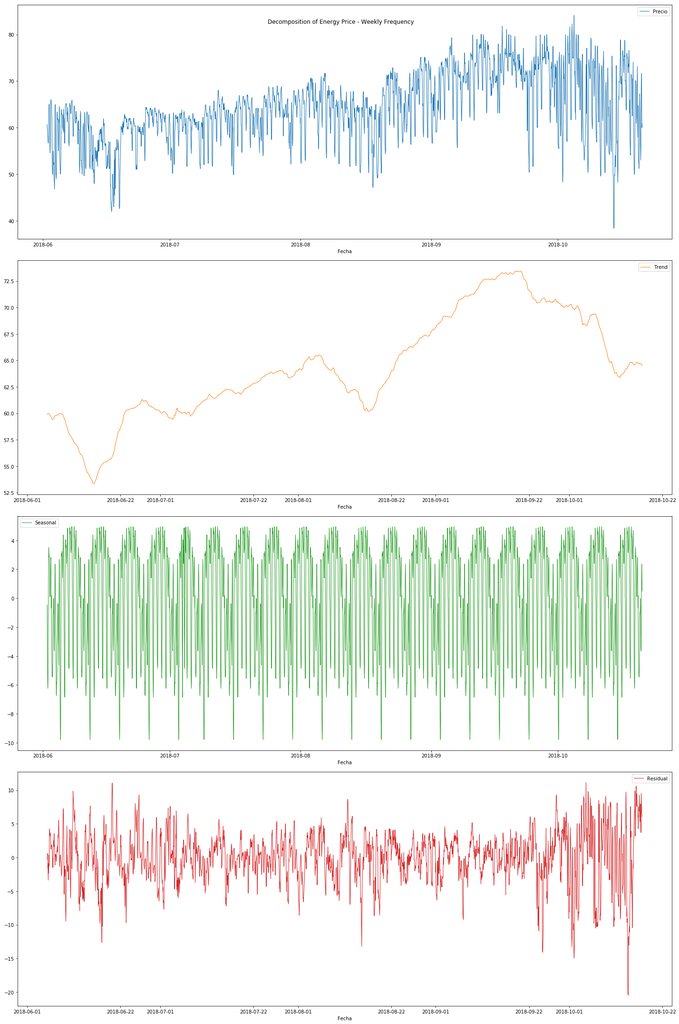

```python
# Import statsmodels.api as sm
import statsmodels.api as sm

df_decomposed = df[['Precio']]

# Perform time series decompositon
decomposition = sm.tsa.seasonal_decompose(df_decomposed, freq=24*7)

df_decomposed['Trend'] = decomposition.trend.values
df_decomposed['Seasonal'] = decomposition.seasonal.values
df_decomposed['Residual'] = decomposition.resid.values


df_decomposed.plot(subplots=True,
                   layout=(4,1),
                   sharex=False,
                   sharey=False,
                   figsize=(20,30),
                   title="Decomposition of Energy Price - Weekly Frequency",
                   linewidth=1
                   )
plt.tight_layout()
plt.show()
```

Esta estacionalidad se confirma en la gráfica siguiente, donde vemos como **el sábado y el domingo son los días donde es más barata la energía.**

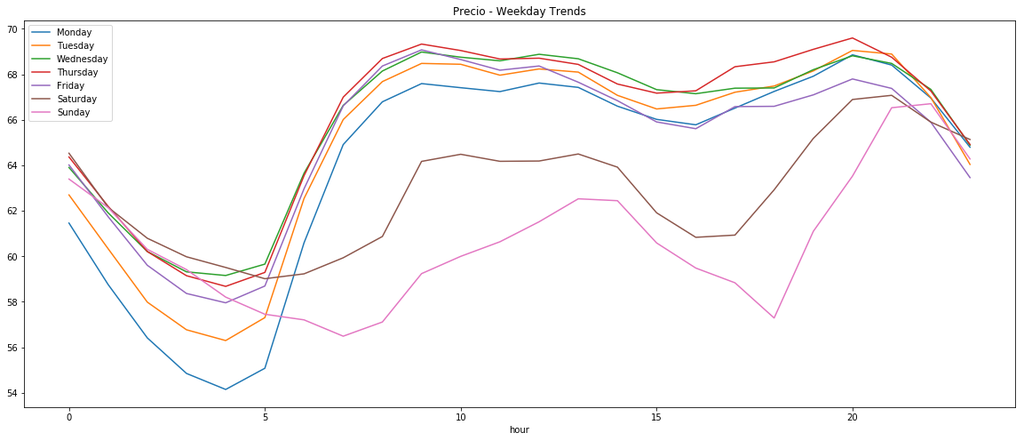

```python
# Mostramos las medias horarias para distintos dias de la semana
df_weekdays = df.pivot_table(index=df['hour'],
                     columns='weekday',
                     values='Precio',
                     aggfunc='mean')
ax=df_weekdays.plot(figsize=(20,8),title='Precio - Weekday Trends')
ax.legend(['Monday','Tuesday','Wednesday','Thursday','Friday','Saturday','Sunday'])
plt.show()
```

En cuanto a la tendencia podemos ver como los meses de **octubre y septiembre tienen los precios más altos.** Además vemos que la curva de octubre es mucho menos suave que el resto, debido a que no tenemos todos los datos para ese mes.

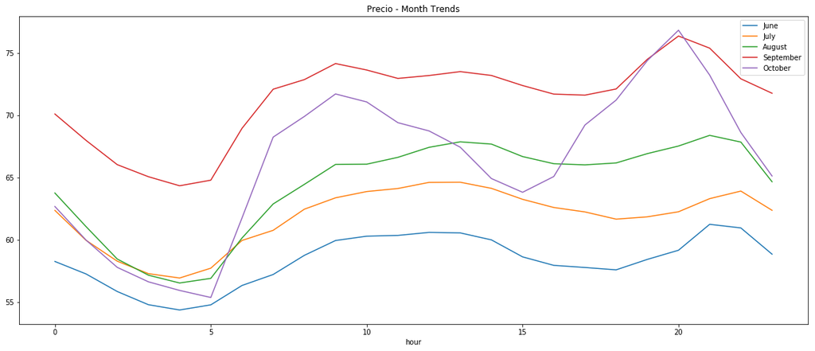

```python
# Mostramos las medias horarias para distintos meses
df_months = df.pivot_table(index=df['hour'],
                     columns='month',
                     values='Precio',
                     aggfunc='mean')
ax = df_months.plot(figsize=(20,8), title='Precio - Month Trends')
ax.legend(['June','July','August','September','October'])

plt.show()
```

## 4. Análisis de los datos.

### 4.1. Test de normalidad

En primer lugar vamos a comprobar que la **variable precio de la energía se comporte de manera gaussiana o normal**, para ello vamos a llevar a cabo una serie de tests de normalidad, que se basan generalmente en los mismos principios:

- Se realizan bajo la suposición de que las muestras son independientes e igualmente distribuidas.
- Las hipótesis son las siguientes:

\begin{align} \ H_0: distribucion \; normal\\ \ H_1: distribución \; no \; normal \end{align}

Las particularidades de cada test quedan fueran del alcance de este documento, en general cada uno comprueba aspectos de una población normal. Nos basta con saber que un buen criterio es rechazar la hipótesis de normalidad si alguno de los test rechaza la hipótesis nula.

```
No handles with labels found to put in legend.
```

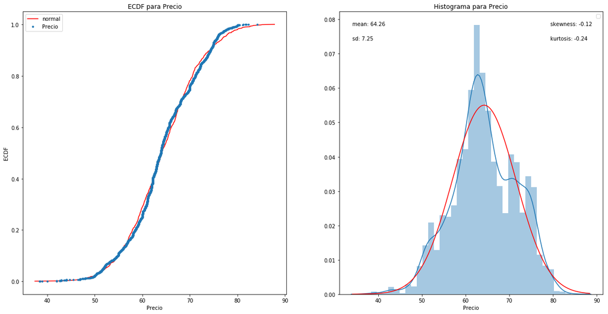

```python
from scipy.stats import kurtosis, skew
from scipy.stats import norm
def plotHist(data,n_bins=None):
    """
    if n_bins = None : Freedman-Diaconis rule
    """
    ax = sns.distplot(data, bins = n_bins, fit=norm, fit_kws={"color":"red"})
    plt.title('Histograma para {}'.format(data.name))
    ax.text(0.8, 0.9,'kurtosis: {}'.format(round(kurtosis(data),2)),
            transform=ax.transAxes)
    ax.text(0.8, 0.95, 'skewness: {}'.format(round(skew(data),2)),
           transform=ax.transAxes)
    ax.text(0.05, 0.95,'mean: {}'.format(round(data.mean(),2)),
            transform=ax.transAxes)
    ax.text(0.05, 0.9, 'sd: {}'.format(round(data.std(),2)),
            transform=ax.transAxes)
    ax.legend()

def plotECDF(data):
    """
    Plot ECDF for a variable and the
    ECDF for a normal distribution with same mean and std
    """
    # create normal distribution with same mean and std as data
    normal = np.random.normal(np.mean(data), np.std(data), 1000)
    # Compute ecdf and plot it in red line
    xvers, yvers = np.sort(normal), np.arange(1, len(normal)+1) / len(normal)
    plt.plot(xvers, yvers, color='red', label='normal')
    xvers, yvers = np.sort(data), np.arange(1, len(data)+1) / len(data)
    plt.plot(xvers, yvers, marker = '.', linestyle = 'none', label=data.name)
    plt.xlabel(data.name)
    plt.ylabel('ECDF')
    plt.title('ECDF para {}'.format(data.name))
    plt.legend()

data = df['Precio']
plt.figure(figsize=(20,10))
plt.subplot(1,2,1)
plotECDF(data)
plt.subplot(1,2,2)
plotHist(data)
```

```python
from scipy.stats import shapiro
from scipy.stats import normaltest
from scipy.stats import anderson
def normality_test(data, alpha=0.05):
    """
    Funcion que nos devuelve los resultados
    de 3 tests distintos de normalidad
    """
    print("Normality Test:")
    print("====================================================")
    print("Shapiro-Wilk test:")
    print("")
    # normality test
    stat, p = shapiro(data)
    print('Statistics=%.3f, p=%.3f' % (stat, p))
    # interpret
    if p > alpha:
        print('Sample looks Gaussian (fail to reject H0)')
    else:
        print('Sample does not look Gaussian (reject H0)')

    print("====================================================")
    print("D'Agostino and Pearson's Test:")
    print("")
    # normality test
    stat, p = normaltest(data)
    print('Statistics=%.3f, p=%.3f' % (stat, p))
    # interpret
    if p > alpha:
        print('Sample looks Gaussian (fail to reject H0)')
    else:
        print('Sample does not look Gaussian (reject H0)')

    print("====================================================")
    print("Anderson-Darling Test:")
    print("")
    # normality test
    result = anderson(data)
    print('Statistic: %.3f' % result.statistic)
    p = 0
    for i in range(len(result.critical_values)):
        sl, cv = result.significance_level[i], result.critical_values[i]
        if result.statistic < result.critical_values[i]:
            print('%.3f: %.3f, data looks normal (fail to reject H0)' % (sl, cv))
        else:
            print('%.3f: %.3f, data does not look normal (reject H0)' % (sl, cv))

normality_test(df['Precio'])
```

```
Normality Test:
====================================================
Shapiro-Wilk test:

Statistics=0.992, p=0.000
Sample does not look Gaussian (reject H0)
====================================================
D'Agostino and Pearson's Test:

Statistics=18.194, p=0.000
Sample does not look Gaussian (reject H0)
====================================================
Anderson-Darling Test:

Statistic: 8.413
15.000: 0.575, data does not look normal (reject H0)
10.000: 0.655, data does not look normal (reject H0)
5.000: 0.786, data does not look normal (reject H0)
2.500: 0.917, data does not look normal (reject H0)
1.000: 1.091, data does not look normal (reject H0)
```

### 4.2. Test de homegeneidad de la varianza

Vamos a realizar un test de homogeneidad de la varianza para comprobar que la varianza de las poblaciones correspondientes a los precios de la energía en fin de semana es igual que la varianza de las medidas durante la semana. Para ello realizaremos hasta tres tipos de tests: **Levene, Bartlett y Fligner-Killeen**.

Los tests se basan en las siguientes hipótesis:

\begin{align} \ H_0: \sigma_1 = \sigma_2 \\ \ H_1: \sigma_1 \neq \sigma_2 \end{align}

Realizamos el test de Bartlett también, aunque al ser muestras no normales, el test de Barlett no nos dirá nada al ser poco robusto ante estas poblaciones.

```python
from scipy.stats import levene, bartlett, fligner

# Poblaciones (findes vs dias de semana)
weekend = df[df.weekend==True]['Precio']
workday = df[df.weekend==False]['Precio']

stat, p = levene(weekend, workday)
print('Levene Test')
print('Statistics=%.3f, p=%.3f' % (stat, p))
print('===================================================')
print('Bartlett Test')
stat, p = bartlett(weekend, workday)
print('Statistics=%.3f, p=%.3f' % (stat, p))
print('===================================================')
print('Fligner Test')
stat, p = fligner(weekend, workday)
print('Statistics=%.3f, p=%.3f' % (stat, p))
print('===================================================')
```

```
Levene Test
Statistics=0.462, p=0.497
===================================================
Bartlett Test
Statistics=0.063, p=0.803
===================================================
Fligner Test
Statistics=0.515, p=0.473
===================================================
```

Todos los tests realizados **fallan al rechazar la hipótesis nula**, por lo que podemos concluir que **las varianzas de nuestras poblaciones son iguales**.

### 4.3. ¿Es el precio de la energía superior en días de semana que en fin de semanas?

Durante los fin de semanas, la mayoría de las industrias y actividades comerciales cesan con lo que el consumo energético cae y los precios bajan. Esto es algo bastante básico y que se confirma al observar la siguiente gráfica donde vemos que durante el día la media de precio por MWh es mucho más baja para el sábado y especialmente el domingo. Algo también lógico es que durante la noche, el precio es más barato, y mucho más durante las noches del domingo al lunes y del lunes al martes, donde se espera una menor actividad lúdica.

El objetivo de esta sección sera comprobar si esta diferencia en el precio entre un día de semana y un día de fin de semana es estadísticamente significativa. Suponemos los datos no apareados por que estrictamente no se trata de la misma población medida en dos momentos distintos en el tiempo, sino es una población que evoluciona. Además, aunque los resultados demostraban **no normalidad** podemos asumir **distribución normal si el número de muestras es mayor a 30 por el Teorema del Límite Central**, el cual es nuestro caso.

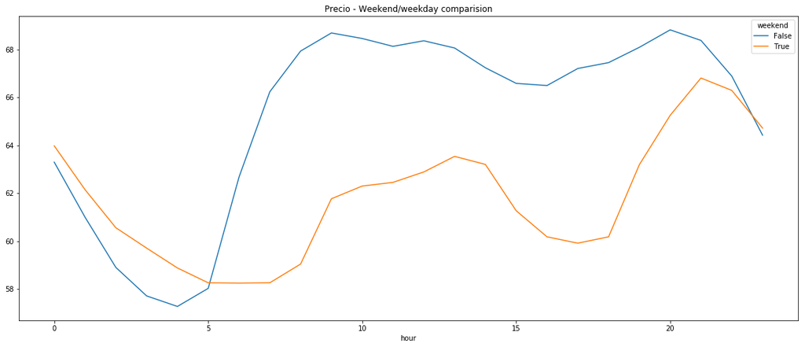

```python
_ = df.pivot_table(index=df['hour'],
                     columns='weekend',
                     values='Precio',
                     aggfunc='mean').plot(figsize=(20,8),
                     title='Precio - Weekend/weekday comparision')
```

```python
# Medias y cuentas de los dos conjuntos
df.groupby('weekend').agg(['count','mean'])['Precio']
```

| weekend | count | mean |
| --- | --- | --- |
| False | 2424 | 65.263127 |
| True | 984 | 61.790325 |

```python
from scipy.stats import ttest_ind
stat, p = ttest_ind(weekend, workday)
print('Statistics=%.3f, p=%.3f' % (stat, p))
```

```
Statistics=-12.976, p=0.000
```

```python
# Test de Mann-Whitney U para distribuciones no normales/varianzas distintas
from scipy.stats import mannwhitneyu
stat, p = mannwhitneyu(weekend, workday)
print('Statistics=%.3f, p=%.3f' % (stat, p))
```

```
Statistics=876101.000, p=0.000
```

El resultado de nuestro test es bastante contudente, **se rechaza la hipótesis nula** con amplia confianza, con lo cual **la diferencia entre las medias es estadísticamente significativa**.

Este resultado se repite tanto para nuestro test parámetrico (student t-test) como para nuestro test no parámetrico Mann-Whitney U.

### 4.4. Estudio de correlación

Vamos a estudiar la correlación existente entre la variable Precio y las variables Ventas y Compras para demostrar que están altamente relacionadas. Como se trata de poblaciones demostradamente no normales, usamos el **test de Spearman's Rank Correlation**. Como podemos ver en el heatmap siguiente, la correlación parece existir entre las variables, con coeficiente de Pearson en valor absoluto cercanos al 0.5.

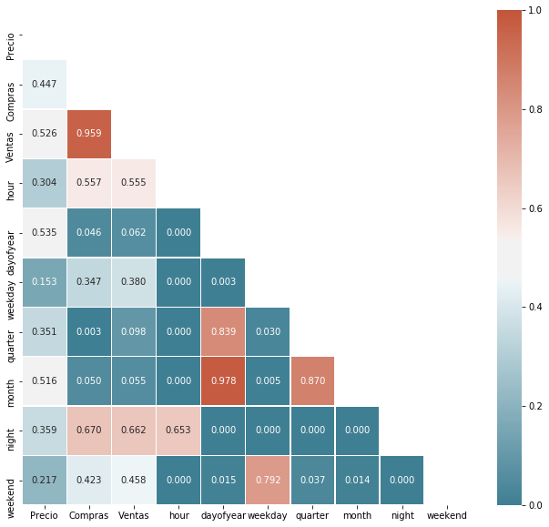

```python
def plotHeatMap(df):
    df = df.dropna()
    # Calculamos la correlacion entre atributos
    corr = df.corr().abs()

    # Generamos una máscara triangular (una matriz del mismo tamaño que la matriz
    # de correlaciones, con valores False en el triángulo inferior y True en el resto).
    mask = np.zeros_like(corr, dtype=np.bool)
    mask[np.triu_indices_from(mask)] = True

    # Generamos la figura matplotlib.
    f, ax = plt.subplots(figsize=(11, 10))

    # Creamos un mapa de colores.
    cmap = sns.diverging_palette(220, 20, sep=20, as_cmap=True)

    # Dibujamos el mapa de calor, utilizando como máscara la matriz mask y
    # los colores especificados.
    sns.heatmap(corr, mask=mask, cmap=cmap,
                xticklabels=list(df), yticklabels=(list(df)),
                annot=True, fmt=".3f",
                linewidths=.5, ax=ax)

#plotHeatMap(df.iloc[:,:3])
plotHeatMap(df)
```

```python
from scipy.stats import spearmanr

df = df
var = 'Precio'
def correlation_test(df, var, typ='spearman'):
    corr_dict = {}
    for col in df.columns:
        if col != var:
            if typ == 'spearman':
                corr_dict[col] = spearmanr(df[var], df[col])
    return pd.DataFrame(corr_dict, index=[typ + ' coef.', 'p-value'])

correlation_test(df, 'Precio')
```

|  | Compras | Ventas | hour | dayofyear | weekday | quarter | month | night | weekend |
| --- | --- | --- | --- | --- | --- | --- | --- | --- | --- |
| spearman coef. | 4.672237e-01 | 5.443645e-01 | 3.103599e-01 | 5.522127e-01 | -1.517167e-01 | 3.695640e-01 | 5.417399e-01 | -3.697039e-01 | -2.083111e-01 |
| p-value | 2.065339e-184 | 2.925416e-262 | 5.408121e-77 | 2.283079e-271 | 5.325479e-19 | 9.029497e-111 | 2.873291e-259 | 7.359477e-111 | 1.007298e-34 |

Los coeficientes de spearman son **estadísticamente relevantes** y determinan que existe una **correlación especialmente fuerte entre precio y las variables compras, ventas y mes**. En el caso de las dos primeras porque existe una causalidad entre ellas, no son independientes, y en el caso del mes resulta bastante más interesante esta relación.

Podemos realizar también el estudio de la **autocorrelación**, que nos dice si una serie temporal está relacionada con una versión "retrasada" o con lag de la misma. Es decir, para un lag 3 nos dice si la serie t1, t2, t3... está relacionada con la serie t4, t5, t6... Para estudiar esto vamos a usarla funcion plot_acf.

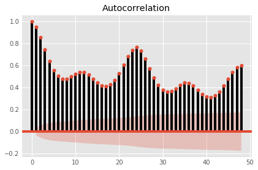

```python
# Import required libraries
import matplotlib.pyplot as plt
plt.style.use('ggplot')

from statsmodels.graphics import tsaplots

# Display the autocorrelation plot of your time series
fig = tsaplots.plot_acf(df[['Precio']], lags=48)

# Show plot
plt.show()
```

### 4.5. Predicción del precio de la energía.

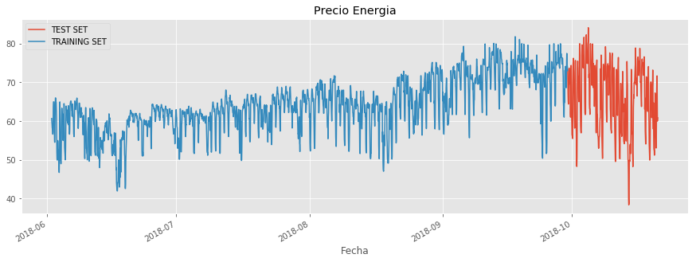

```python
# Preparacion de datos para prediccion

# Separamos los valores train/test a partir del 1 de octubre
split_date = '30-09-2018'
train = df.loc[df.index <= split_date].copy()
test = df.loc[df.index > split_date].copy()

# Ploteamos train y test
plt.style.use('ggplot')
_ = test[['Precio']].rename(columns={'Precio': 'TEST SET'}) \
    .join(train[['Precio']].rename(columns={'Precio': 'TRAINING SET'}), how='outer') \
    .plot(figsize=(15,5), title='Precio Energia', style='-')

# Separamos en X, y
X_train = train.reset_index().iloc[:,4:9]
X_test = test.reset_index().iloc[:,4:9]
y_train = train.reset_index().iloc[:,1:2]
y_test = test.reset_index().iloc[:,1:2]
```

```python
# Calculamos los errores
from sklearn.metrics import mean_squared_error, mean_absolute_error

def getRegressionErrors(y_true, y_pred):
    """
    A partir de un array con valores verdaderos y uno de predicciones
    devuelve los errores cometidos por el modelo:
    MSE - Mean Squared Error
    MAE - Mean Absolute Error
    MAPE - Mean Absolute Percentage Error
    """
    # Transformamos variables a arrays
    y_true = np.array(y_true)
    y_pred = np.array(y_pred)

    # Calculamos los errores
    MSE = mean_squared_error(y_true, y_pred)
    MAE = mean_absolute_error(y_true, y_pred)
    MAPE = np.mean(np.abs((y_true - y_pred) / y_true)) * 100

    print("Regression Error Report:")
    print("MSE: %.2f" % MSE)
    print("MAE: %.2f" % MAE)
    print("MAPE: %.2f %%" % MAPE)

    return MSE, MAE, MAPE
```

#### Modelo de Regresion lineal Multiple

```python
from sklearn.linear_model import LinearRegression

# Inicializamos el modelo y lo entrenamos
lm = LinearRegression()
lm.fit(X_train,y_train)

# Realizamos predicciones
y_pred = lm.predict(X_test)

# Errores del modelo
_ = getRegressionErrors(y_test, y_pred)
```

```
Regression Error Report:
MSE: 107.03
MAE: 7.95
MAPE: 13.63 %
```

```python
# Coeficientes del modelo lineal
lm.coef_
```

```
array([[ 0.27842825,  0.11531724, -0.46744524, -2.00026919,  1.24200844]])
```

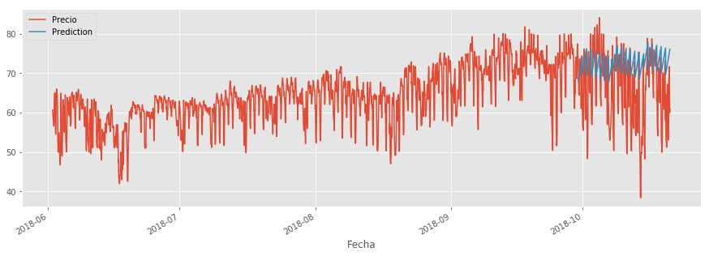

```python
# Realizamos una prediccion y representamos
test['Prediction'] = y_pred
data = pd.concat([test, train], sort=False)

_ = data[['Precio','Prediction']].plot(figsize=(15, 5))
```

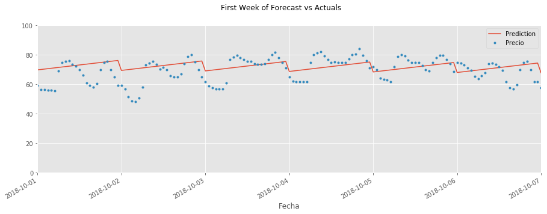

```python
# Representamos la primera semana de predicciones
f, ax = plt.subplots(1)
f.set_figheight(5)
f.set_figwidth(15)
_ = data[['Prediction','Precio']].plot(ax=ax, style=['-','.'])
ax.set_xbound(lower='10-01-2018', upper='10-07-2018')
ax.set_ylim(0, 100)
plot = plt.suptitle('First Week of Forecast vs Actuals')
```

#### Predicción usando el modelo Xtreme Gradient Boosting

Vamos a entrenar un modelo XGBoost basado en el concepto de boosting con árboles de decisión debido a que este modelo usa la salida ponderada de todos estos árboles construyendo un modelo **no lineal**. Para ello necesitamos un formato especifico en nuestros datos, esto es:

- Dividiremos los datos en conjunto de train y test (el conjutno de test será a partir del 1 de octubre, es decir, un sexto de los datos totales).
- Usaremos la variable Precio como target y las variables temporales hour, dayofyear, weekday, quarter y month como las variables predictoras, por tanto no necesitaremos la variable fecha, ni las demás.

```python
# Importamos la libreria xgboost y las funciones para calcular el rendimiento del modelo MSE y MAE
import xgboost as xgb

# Creamos un regresor con 1000 arboles de decision y lo entrenamos sobre train
reg = xgb.XGBRegressor(objective='reg:linear',n_estimators=1000)
reg.fit(X_train, y_train,
        eval_set=[(X_train, y_train), (X_test, y_test)],
        early_stopping_rounds=50,
       verbose=False)
```

```
XGBRegressor(base_score=0.5, booster='gbtree', colsample_bylevel=1,
       colsample_bytree=1, gamma=0, learning_rate=0.1, max_delta_step=0,
       max_depth=3, min_child_weight=1, missing=None, n_estimators=1000,
       n_jobs=1, nthread=None, objective='reg:linear', random_state=0,
       reg_alpha=0, reg_lambda=1, scale_pos_weight=1, seed=None,
       silent=True, subsample=1)
```

```python
# Calculamos las predicciones
y_pred = reg.predict(X_test)

# Calculamos los errores
_ = getRegressionErrors(y_test, y_pred)
```

```
Regression Error Report:
MSE: 52.73
MAE: 6.04
MAPE: 12.52 %
```

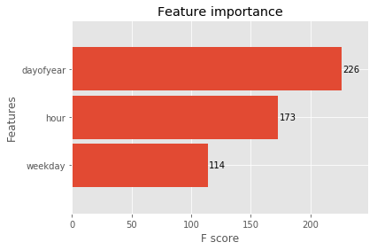

```python
# Ploteamos la importancia de las variables independientes
_ = xgb.plot_importance(reg, height=0.9)
```

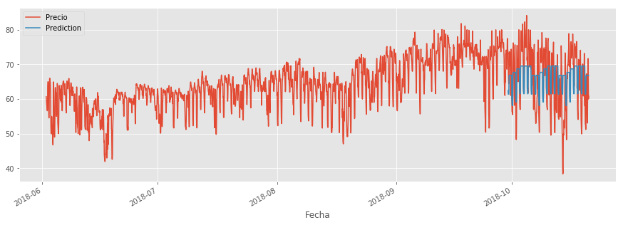

```python
# Realizamos una prediccion y representamos
test['Prediction'] = y_pred
data = pd.concat([test, train], sort=False)

_ = data[['Precio','Prediction']].plot(figsize=(15, 5))
```

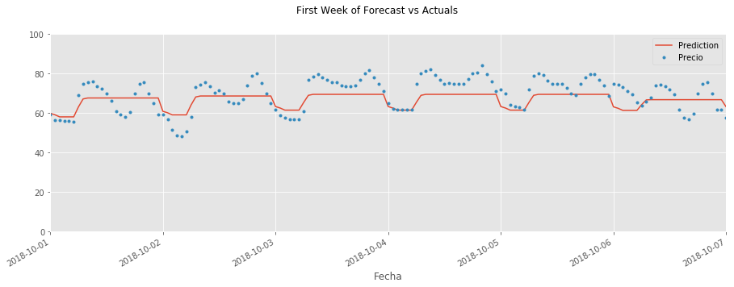

```python
# Representamos la primera semana de predicciones
f, ax = plt.subplots(1)
f.set_figheight(5)
f.set_figwidth(15)
_ = data[['Prediction','Precio']].plot(ax=ax, style=['-','.'])
ax.set_xbound(lower='10-01-2018', upper='10-07-2018')
ax.set_ylim(0, 100)
plot = plt.suptitle('First Week of Forecast vs Actuals')
```

```python
# Peores casos
test['error'] = test['Precio'] - test['Prediction']
test['abs_error'] = test['error'].apply(np.abs)
error_by_day = test.groupby(['weekday']) \
    .mean()[['Precio','Prediction','error','abs_error']]

# Over forecasted days
error_by_day.sort_values('abs_error', ascending=False).head(10)
```

| weekday | Precio | Prediction | error | abs_error |
| --- | --- | --- | --- | --- |
| 6 | 61.078028 | 65.529289 | -4.451263 | 8.693104 |
| 5 | 63.195417 | 65.497299 | -2.301879 | 6.500009 |
| 4 | 65.740417 | 67.469795 | -1.729381 | 5.734870 |
| 1 | 69.766667 | 66.227913 | 3.538756 | 5.564628 |
| 2 | 70.229583 | 67.469795 | 2.759786 | 5.307181 |
| 3 | 68.016667 | 67.469795 | 0.546869 | 5.283262 |
| 0 | 66.165972 | 65.218872 | 0.947102 | 5.243228 |

El modelo **solo es capaz de capturar las diferencias entre el día y la noche**, no consiguiendo predecir los cambios en los fin de semana (vemos en la tabla de arriba que se cometen los mayores errores en fin de semana) ni tampoco los ciclos propios de los días.

- No tenemos datos suficiente para capturar los efectos de estacionalidad (con datos de apenas 4 meses y medio es complicado predecir un mes que nunca ha visto). Necesitaríamos un tamaño más cercano a los 5 años que a los pocos meses para obtener resultados decentes.
- No tenemos variables que afectan notablemente al precio de la energía como lo son **predicción de consumo de la REE y su homologa portuguesa, datos climatológicos, niveles de las presas, etc**.

## Conclusiones.

Los objetivos alcanzados en el desarollo de este documento incluyen:

- Se ha demostrado que **el precio de la energía depende fuertemente de los ciclos diarios y semanales**.
- Se ha probado que el precio de la energía tiene una **correlación con el mes** según nuestros datos, aunque el modelo despreciaba esa variable. Además, las series tienen una **fuerte autocorrelación con los datos inmediatos y los desplazados 24h, es decir, la misma hora del día siguiente**.
- Se ha intentado realizar un modelo de predicción a corto alcance que resultó ser muy conservador durante el día y no conseguía capturar las diferencias probadas entre día laboral y fin de semana. Aunque capturaba bien las diferencias entre el día y la noche.

Los pasos posteriores en cuanto al análisis del precio de la energía suponen los siguientes puntos:

- Ampliar el conjunto de datos extraidos de OMIE.es para incluir un conjunto histórico de 5 años.
- Incluir los días festivos y otras variables que permitan cuantificar los patrones de consumo de energía como las propias predicciones de la REE.
- Incluir datos meteorológicos y de niveles de embalses así como variables de mercado (precio de gas, petroleo).
- Optmizar los hiperparámetros del modelo y probar otros como ARIMA o el algoritmo Prophet.